# 心臟病ML練習

C.C.

2019/9/27

# 前言

這一份有關於心臟病的Rmd 主要是為了以下三個目的:

1.學習查找文章  
2.學習機械學習的相關工具  
3.學習資料視覺化的相關技巧

# 分析步驟

1.資料載入與檢視  
2.資料探勘  
3.資料前處理  
4.產生訓練資料集與測試資料集  
5.篩選變數  
6.訓練模型與預測  
7.模型診斷與調整  
8.模型比較(v.s. Machine Learning Methods)

# 資料(raw data)

## 變數說明

1.年齡(age) : 該人的年齡（歲）  
2.性別(sex ) : 人的性別（1 = 男性，0 = 女性）  
3.cp : 經歷過的胸痛（值1：典型心絞痛，值2：非典型性心絞痛，值3：非心絞痛，值4：無症狀）  
4.trestbps : 該人的靜息血壓（入院時的毫米汞柱）  
5.cholmg / dl : 人的膽固醇測量值，mg / dl  
6.fbs : 該人的空腹血糖（120 mg / dl，1 = true； 0 = false）  
7.restecg : 靜息心電圖測量 (0 = normal, 1 = 有ST-T波異常, 2 = 根據Estes的標準顯示可能或確定的左心室肥大)  
8.thalach : 該人達到的最大心率  
9.exang : 運動誘發的心絞痛(1 = yes; 0 = no)  
10. oldpeak : 運動引起的ST段壓低相對於休息(ST”與ECG圖上的位置有關)  
11.slope : 運動高峰ST段的斜率(Value 1: 上升, Value 2: 平, Value 3: 下降)  
12.ca : 大血管（0-3）的數量(number of major vessels (0-3) colored by flourosopy)  
13.thal ： 一種稱為地中海貧血的血液疾病(3 = normal; 6 = 固定缺陷; 7 = 可逆缺陷)  
14.target : 心臟病 1 or 0

## 資料表(tabsets)

|  | age | sex | cp | trestbps | chol | fbs | restecg | thalach | exang | oldpeak | slope | ca | thal | target |
| --- | --- | --- | --- | --- | --- | --- | --- | --- | --- | --- | --- | --- | --- | --- |
| 1 | 63 | 1 | 3 | 145 | 233 | 1 | 0 | 150 | 0 | 2.3 | 0 | 0 | 1 | 1 |
| 2 | 37 | 1 | 2 | 130 | 250 | 0 | 1 | 187 | 0 | 3.5 | 0 | 0 | 2 | 1 |
| 3 | 41 | 0 | 1 | 130 | 204 | 0 | 0 | 172 | 0 | 1.4 | 2 | 0 | 2 | 1 |
| 4 | 56 | 1 | 1 | 120 | 236 | 0 | 1 | 178 | 0 | 0.8 | 2 | 0 | 2 | 1 |
| 5 | 57 | 0 | 0 | 120 | 354 | 0 | 1 | 163 | 1 | 0.6 | 2 | 0 | 2 | 1 |
| 6 | 57 | 1 | 0 | 140 | 192 | 0 | 1 | 148 | 0 | 0.4 | 1 | 0 | 1 | 1 |
| 7 | 56 | 0 | 1 | 140 | 294 | 0 | 0 | 153 | 0 | 1.3 | 1 | 0 | 2 | 1 |
| 8 | 44 | 1 | 1 | 120 | 263 | 0 | 1 | 173 | 0 | 0 | 2 | 0 | 3 | 1 |
| 9 | 52 | 1 | 2 | 172 | 199 | 1 | 1 | 162 | 0 | 0.5 | 2 | 0 | 3 | 1 |
| 10 | 57 | 1 | 2 | 150 | 168 | 0 | 1 | 174 | 0 | 1.6 | 2 | 0 | 2 | 1 |

[output cut: 293 more lines]

## 變數屬性 與 概要

```
## Classes 'spec_tbl_df', 'tbl_df', 'tbl' and 'data.frame': 303 obs. of  14 variables:
##  $ age     : num  63 37 41 56 57 57 56 44 52 57 ...
##  $ sex     : Factor w/ 2 levels "0","1": 2 2 1 2 1 2 1 2 2 2 ...
##  $ cp      : Factor w/ 4 levels "0","1","2","3": 4 3 2 2 1 1 2 2 3 3 ...
##  $ trestbps: num  145 130 130 120 120 140 140 120 172 150 ...
##  $ chol    : num  233 250 204 236 354 192 294 263 199 168 ...
##  $ fbs     : Factor w/ 2 levels "0","1": 2 1 1 1 1 1 1 1 2 1 ...
##  $ restecg : Factor w/ 3 levels "0","1","2": 1 2 1 2 2 2 1 2 2 2 ...
##  $ thalach : num  150 187 172 178 163 148 153 173 162 174 ...
##  $ exang   : Factor w/ 2 levels "0","1": 1 1 1 1 2 1 1 1 1 1 ...
##  $ oldpeak : num  2.3 3.5 1.4 0.8 0.6 0.4 1.3 0 0.5 1.6 ...
##  $ slope   : Factor w/ 3 levels "0","1","2": 1 1 3 3 3 2 2 3 3 3 ...
##  $ ca      : Factor w/ 5 levels "0","1","2","3",..: 1 1 1 1 1 1 1 1 1 1 ...
##  $ thal    : Factor w/ 4 levels "0","1","2","3": 2 3 3 3 3 2 3 4 4 3 ...
##  $ target  : Factor w/ 2 levels "0","1": 2 2 2 2 2 2 2 2 2 2 ...
##  - attr(*, "spec")=
##   .. cols(
##   ..   age = col_double(),
##   ..   sex = col_factor(levels = c(0, 1), ordered = FALSE, include_na = FALSE),
##   ..   cp = col_factor(levels = c(0, 1, 2, 3), ordered = FALSE, include_na = FALSE),
##   ..   trestbps = col_double(),
##   ..   chol = col_double(),
##   ..   fbs = col_factor(levels = c(0, 1), ordered = FALSE, include_na = FALSE),
##   ..   restecg = col_factor(levels = c(0, 1, 2), ordered = FALSE, include_na = FALSE),
##   ..   thalach = col_double(),
##   ..   exang = col_factor(levels = c(0, 1), ordered = FALSE, include_na = FALSE),
##   ..   oldpeak = col_double(),
##   ..   slope = col_factor(levels = c(0, 1, 2), ordered = FALSE, include_na = FALSE),
##   ..   ca = col_factor(levels = c(0, 1, 2, 3, 4), ordered = FALSE, include_na = FALSE),
##   ..   thal = col_factor(levels = c(0, 1, 2, 3), ordered = FALSE, include_na = FALSE),
##   ..   target = col_factor(levels = c(0, 1), ordered = FALSE, include_na = FALSE)
##   .. )
```

|  | age | sex | cp | trestbps | chol | fbs | restecg | thalach | exang | oldpeak | slope | ca | thal | target |
| --- | --- | --- | --- | --- | --- | --- | --- | --- | --- | --- | --- | --- | --- | --- |
|  | Min. :29.00 | 0: 96 | 0:143 | Min. : 94.0 | Min. :126.0 | 0:258 | 0:147 | Min. : 71.0 | 0:204 | Min. :0.00 | 0: 21 | 0:175 | 0: 2 | 0:138 |
|  | 1st Qu.:47.50 | 1:207 | 1: 50 | 1st Qu.:120.0 | 1st Qu.:211.0 | 1: 45 | 1:152 | 1st Qu.:133.5 | 1: 99 | 1st Qu.:0.00 | 1:140 | 1: 65 | 1: 18 | 1:165 |
|  | Median :55.00 | NA | 2: 87 | Median :130.0 | Median :240.0 | NA | 2: 4 | Median :153.0 | NA | Median :0.80 | 2:142 | 2: 38 | 2:166 | NA |
|  | Mean :54.37 | NA | 3: 23 | Mean :131.6 | Mean :246.3 | NA | NA | Mean :149.6 | NA | Mean :1.04 | NA | 3: 20 | 3:117 | NA |
|  | 3rd Qu.:61.00 | NA | NA | 3rd Qu.:140.0 | 3rd Qu.:274.5 | NA | NA | 3rd Qu.:166.0 | NA | 3rd Qu.:1.60 | NA | 4: 5 | NA | NA |
|  | Max. :77.00 | NA | NA | Max. :200.0 | Max. :564.0 | NA | NA | Max. :202.0 | NA | Max. :6.20 | NA | NA | NA | NA |

## 資料探勘(Exploratory Data Analysis)

### 年齡(Age)分組 有心臟病分布情況

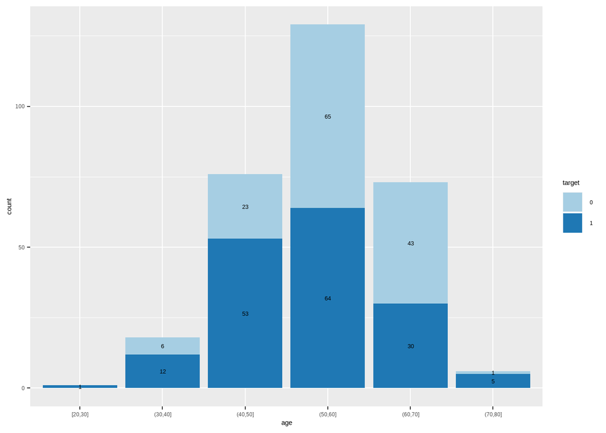

### sex 分組 有心臟病分布情況

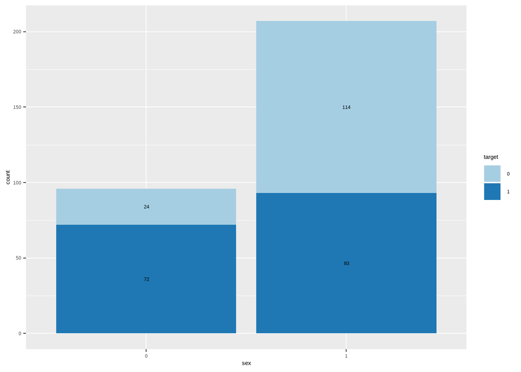

### cp 分組 有心臟病分布情況

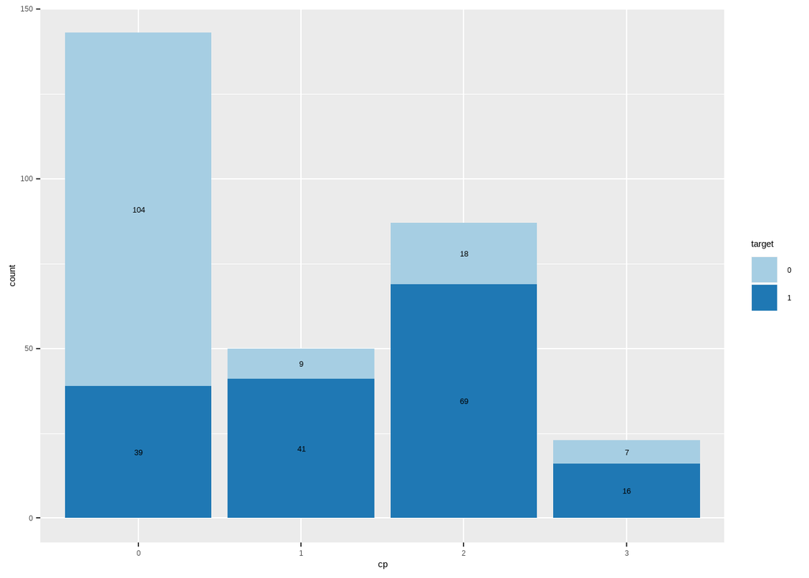

### trestbps 分組 有心臟病分布情況

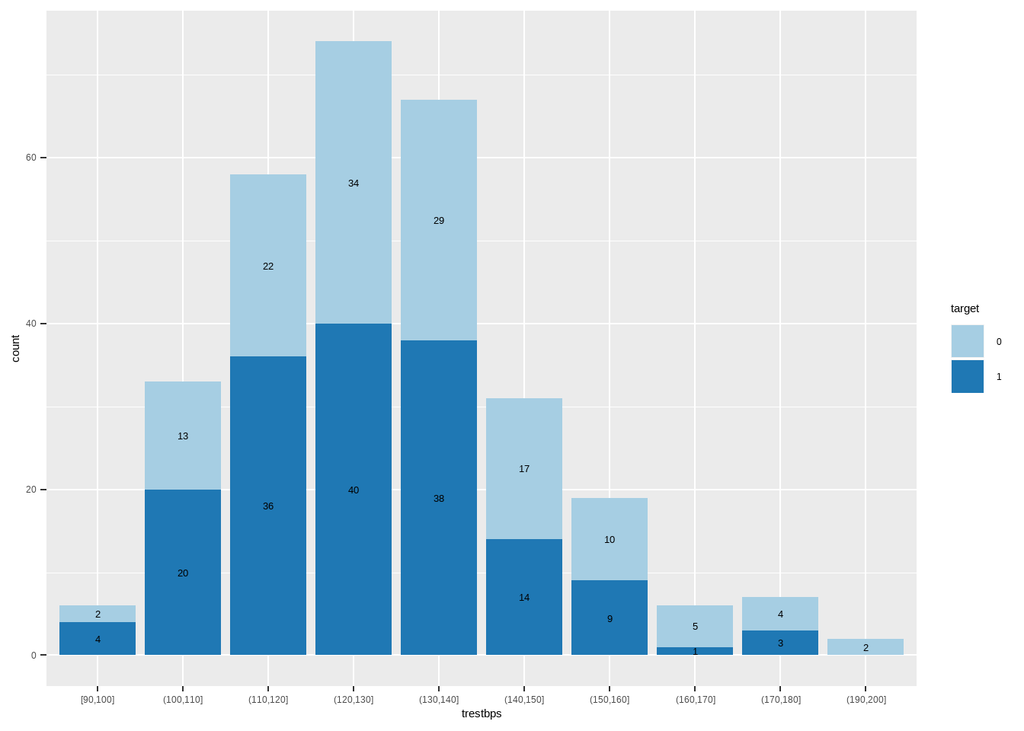

### chol 分組 有心臟病分布情況

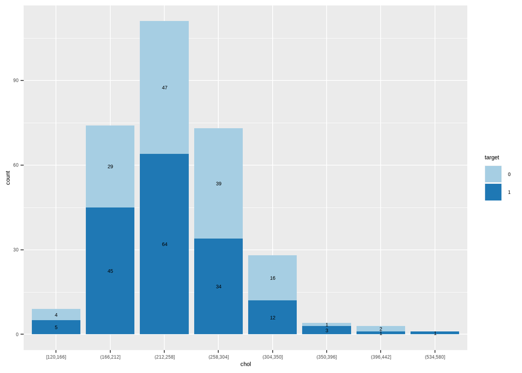

### fbs 分組 有心臟病分布情況

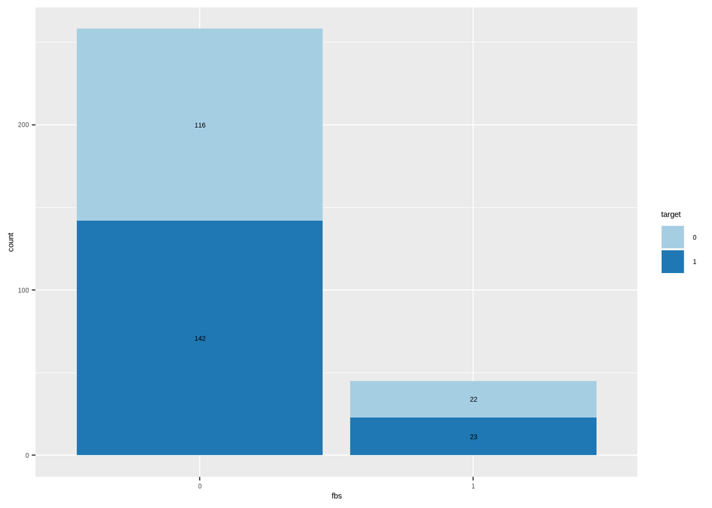

### restecg 分組 有心臟病分布情況

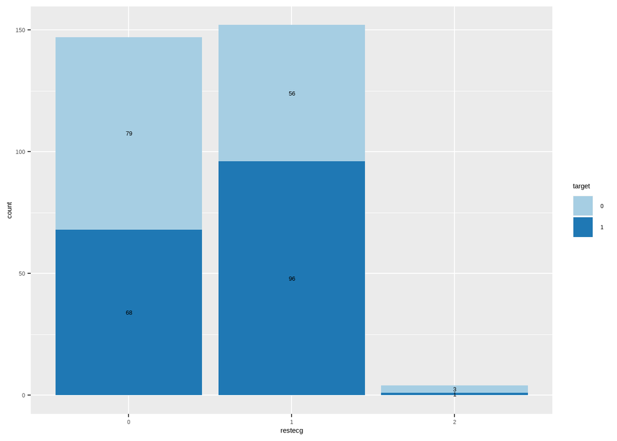

### thalach 分組 有心臟病分布情況

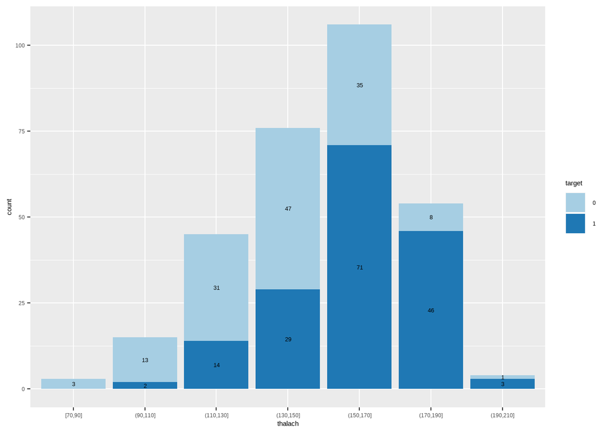

### exang 分組 有心臟病分布情況

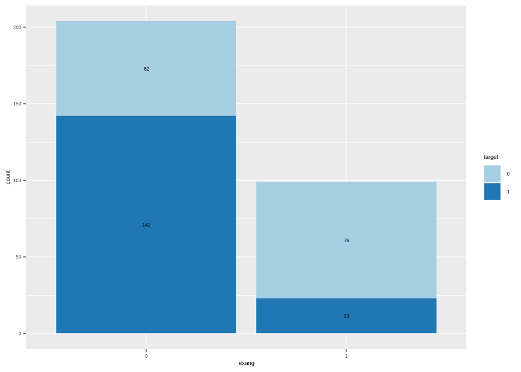

### oldpeak 分組 有心臟病分布情況

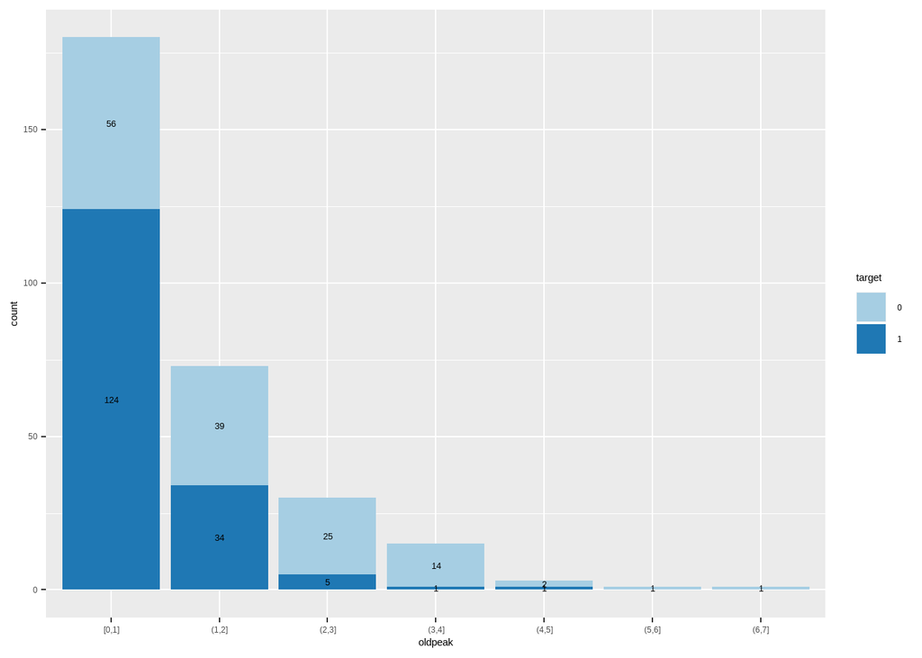

### slope 分組 有心臟病分布情況

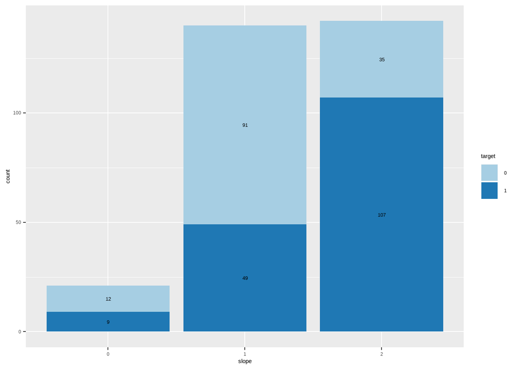

### ca 分組 有心臟病分布情況

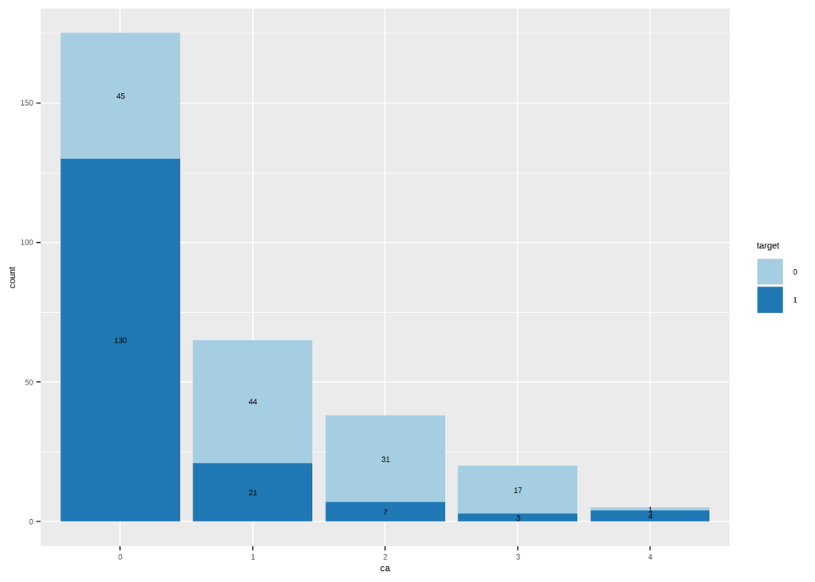

### thal 分組 有心臟病分布情況

[figure not shown]

# 邏輯斯迴歸(Logistic regression)

## 產生訓練資料集與測試資料集

```r
#分割訓練集和測試集
set.seed(1234)
lr.split <- initial_split(df, ratio = 0.7)
lr.train <- training(lr.split)
lr.test <- testing(lr.split)
```

## 計算IV (Information Value) 值，篩選變數

關於IV Table的部分，我們可以得出以下資訊：  
1.根據經驗，IV>=0.3即表示該預測變數與目標變數有較強的關係。  
2.類別變數IV=0表示類別水準值過多。  
3.連續變數IV=0表示沒有顯著的切點存在。

```
##        VARS IV
## 1       sex  0
## 2        cp  0
## 3       fbs  0
## 4   restecg  0
## 5     exang  0
## 6     slope  0
## 7      thal  0
## 8       age  0
## 9  trestbps  0
## 10     chol  0
## 11  thalach  0
## 12  oldpeak  0
```

## 訓練模型與預測

```
##
## Call:
## glm(formula = target ~ age + sex + cp + thalach + ca, family = binomial(link = "logit"),
##     data = lr.train)
##
## Deviance Residuals:
##     Min       1Q   Median       3Q      Max
## -2.1211  -0.4846   0.1996   0.5728   2.7836
##
## Coefficients:
##             Estimate Std. Error z value Pr(>|z|)
## (Intercept) -5.93814    2.44012  -2.434 0.014952 *
## age          0.02459    0.02463   0.998 0.318110
## sex1        -1.48521    0.46994  -3.160 0.001575 **
## cp1          1.93930    0.55754   3.478 0.000505 ***
## cp2          2.28563    0.49676   4.601  4.2e-06 ***
## cp3          1.67553    0.68362   2.451 0.014247 *
## thalach      0.03752    0.01101   3.409 0.000651 ***
## ca1         -1.94339    0.50671  -3.835 0.000125 ***
## ca2         -2.79736    0.72394  -3.864 0.000112 ***
## ca3         -2.62628    0.93027  -2.823 0.004756 **
## ca4          0.23868    1.45785   0.164 0.869952
## ---
## Signif. codes:  0 '***' 0.001 '**' 0.01 '*' 0.05 '.' 0.1 ' ' 1
##
## (Dispersion parameter for binomial family taken to be 1)
##
##     Null deviance: 314.65  on 227  degrees of freedom
## Residual deviance: 172.28  on 217  degrees of freedom
## AIC: 194.28
##
## Number of Fisher Scoring iterations: 5
```

## 模型共線性檢查VIF(希望VIF值都在4以下)

```
##             GVIF Df GVIF^(1/(2*Df))
## age     1.361634  1        1.166891
## sex     1.135028  1        1.065377
## cp      1.244102  3        1.037073
## thalach 1.283383  1        1.132865
## ca      1.405074  4        1.043428
```

## 預測測試資料集

最適機率切點為: 0.2883186

```
## [1] 0.2883186
```

決定了機率切點後，我們來驗證模型使用測試資料集的預測效果如何。我們會分別計算以下指標：

1.Confusion Matrix  
2.misClassification Rate  
3.precision  
4.Sensitivity  
5.Specifisity  
6.Concordance  
7.ROC/AUC

> 1.Confusion Matrix: 左欄為預測值，上方欄則為實際值。

```
##    0  1
## 0 23  2
## 1 10 40
```

> 2.預測錯誤率(misClassification Rate)

```
## [1] 0.16
```

> 3.預測精準度(Precision，及所有預測為1的事件中，真實亦為1的事件比率）。

```
## [1] 0.8
```

> 4.Sensitivity 又稱Recall(捕捉率），即真實為1，且被正確預測為1的比例。（通常與Precision精準度成反比）

```
## [1] 0.952381
```

> 5.Specifisity 即真實為0，且被正確預測為0的比例。

```
## [1] 0.6969697
```

> 6.Concordance 則為所有預測結果(0,1)成對的機率值中，真實為1的事件，1的機率高於0的機率佔所有成對資料的比例。理想中，該比例越高越好，即表示所有預測(0,1)的機率值，若真實為1，則1的預測機率理應都大於0的預測機率。（discordance則為相反結果的比例，tied則為機率無差別的結果比例，三比例相加應為100%）。

```
## $Concordance
## [1] 0.8578644
##
## $Discordance
## [1] 0.1421356
##
## $Tied
## [1] -2.775558e-17
##
## $Pairs
## [1] 1386
```

> 7.ROC/AUC 可以發現在ROC曲線下面積為85.43%。理想中，會希望ROC曲線前段越陡越好，後段越緩越好。表示模型整體預測能力的好壞。

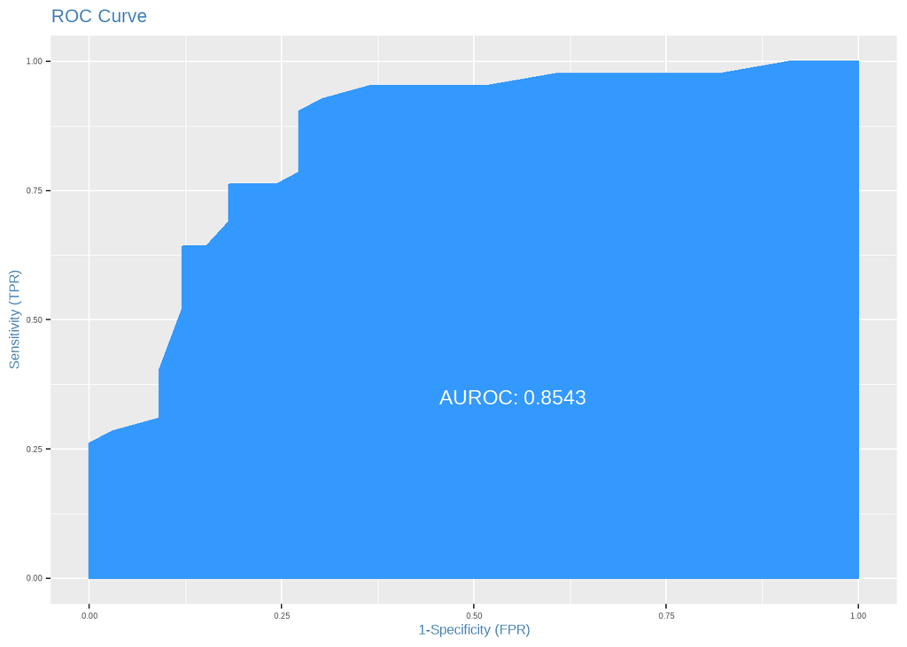

## 模型診斷與調整

為了近一步看看模型有無優化空間以及合適度，常見做法包括  
(1)殘差分析  
(2)K-fold Cross Validation  
(3)Bootstrap  
(4)StepwiseRegression  
我們這邊就以逐步回歸為範例，來看看模型是否有優化空間。

```
##
## Call:
## glm(formula = target ~ sex + cp + thalach + ca, family = binomial(link = "logit"),
##     data = lr.train)
##
## Deviance Residuals:
##     Min       1Q   Median       3Q      Max
## -2.1889  -0.5006   0.1996   0.5647   2.7913
##
## Coefficients:
##             Estimate Std. Error z value Pr(>|z|)
## (Intercept) -4.04632    1.50344  -2.691 0.007116 **
## sex1        -1.53538    0.46484  -3.303 0.000956 ***
## cp1          1.94576    0.55665   3.496 0.000473 ***
## cp2          2.28450    0.49413   4.623 3.78e-06 ***
## cp3          1.74189    0.67942   2.564 0.010354 *
## thalach      0.03374    0.01023   3.298 0.000975 ***
## ca1         -1.83559    0.49066  -3.741 0.000183 ***
## ca2         -2.60622    0.69307  -3.760 0.000170 ***
## ca3         -2.47433    0.91208  -2.713 0.006671 **
## ca4          0.10484    1.42549   0.074 0.941370
## ---
## Signif. codes:  0 '***' 0.001 '**' 0.01 '*' 0.05 '.' 0.1 ' ' 1
##
## (Dispersion parameter for binomial family taken to be 1)
##
##     Null deviance: 314.65  on 227  degrees of freedom
## Residual deviance: 173.28  on 218  degrees of freedom
## AIC: 193.28
##
## Number of Fisher Scoring iterations: 5
```

# 決策樹(decision tree)

# 支持向量機(SVM)

# 梯度提升(GBM)

# 極限梯度提升 (xgboost)